# Car Depreciation Analysis - Germany Used Car Market

Shiheng Xu

2025-11-10

# Introduction

Understanding car depreciation is crucial for both buyers and sellers in the used car market. Cars are typically one of the largest purchases people make, and unlike real estate, they lose value over time. This analysis examines the German automotive market using data from AutoScout24, one of Europe’s largest car marketplaces, to answer three fundamental questions about how cars lose value.

**Why This Matters:** - **For Buyers:** Knowing depreciation patterns helps identify the best time to buy and which vehicles hold their value - **For Sellers:** Understanding when cars lose the most value helps determine optimal selling timing - **For the Market:** Depreciation patterns reveal consumer preferences and brand value perceptions

## Research Questions

This study investigates three key questions:

1. **How much value do cars lose per year?**  
   *Quantifying the average annual depreciation rate provides a baseline for understanding car value loss.*
2. **Do luxury brands (BMW, Mercedes) depreciate differently than economy brands (Volkswagen, Opel)?**  
   *Luxury cars cost significantly more upfront, but do they depreciate faster, slower, or at the same rate as economy vehicles?*
3. **Is there an interaction between mileage and age in determining price?**  
   *Does high mileage hurt newer cars more than older cars, or vice versa? Understanding this interaction reveals important non-linear pricing dynamics.*

# 1. Data Overview

## 1.1 Load Cleaned Dataset

We begin by loading our cleaned dataset, which has been preprocessed to remove outliers, duplicates, and missing values.

```r
cars <- read.csv("data/cars_cleaned.csv", stringsAsFactors = FALSE)

cat("✓ Cleaned dataset loaded!\n")
```

```
## ✓ Cleaned dataset loaded!
```

```r
cat("Observations:", nrow(cars), "\n")
```

```
## Observations: 44048
```

```r
cat("Variables:", ncol(cars), "\n\n")
```

```
## Variables: 9
```

```r
cat("Variables:\n")
```

```
## Variables:
```

```r
print(names(cars))
```

```
## [1] "mileage"   "make"      "model"     "fuel"      "gear"      "offerType"
## [7] "price"     "hp"        "year"
```

```r
cat("\nFirst few rows:\n")
```

```
##
## First few rows:
```

```r
print(head(cars))
```

```
##   mileage       make  model              fuel      gear offerType price  hp
## 1  235000        BMW    316            Diesel    Manual      Used  6800 116
## 2   92800 Volkswagen   Golf          Gasoline    Manual      Used  6877 122
## 3  149300       SEAT   Exeo          Gasoline    Manual      Used  6900 160
## 4   96200    Renault Megane          Gasoline    Manual      Used  6950 110
## 5  156000    Peugeot    308          Gasoline    Manual      Used  6950 156
## 6  147000     Toyota  Auris Electric/Gasoline Automatic      Used  6950  99
##   year
## 1 2011
## 2 2011
## 3 2011
## 4 2011
## 5 2011
## 6 2011
```

**Dataset Characteristics:** - **44,048 observations:** After removing 5% of problematic data (extreme outliers, duplicates) - **Time period:** 2011-2021 (11 years of vehicle data) - **Geographic scope:** Germany (one of Europe’s largest automotive markets) - **Source:** AutoScout24 marketplace listings

**Key Variables:** - `price`: Sale price in euros (dependent variable) - `mileage`: Kilometers driven (key depreciation factor) - `year`: Manufacturing year (converted to age for analysis) - `hp`: Horsepower (performance indicator) - `make`: Manufacturer/brand - `fuel`: Fuel type (Diesel, Gasoline, Electric, etc.) - `gear`: Transmission type (Manual, Automatic, Semi-automatic) - `offerType`: New, Used, Pre-registered, etc.

# 2. Feature Engineering

To answer our research questions effectively, we create three derived variables that transform raw data into more analytically useful forms.

```r
# Calculate car age from manufacturing year
cars$car_age <- 2025 - cars$year

# Classify brands into market segments
cars$brand_category <- ifelse(cars$make %in%
                               c("BMW", "Mercedes-Benz", "Audi", "Porsche"),
                               "Luxury",
                               ifelse(cars$make %in%
                                      c("Volkswagen", "Opel", "Ford", "Renault",
                                        "Skoda", "SEAT", "Hyundai", "Kia"),
                                      "Economy",
                                      "Mid-Range"))

# Scale mileage to thousands for easier interpretation
cars$mileage_1000 <- cars$mileage / 1000

cat("New variables created:\n")
```

```
## New variables created:
```

```r
cat("✓ car_age: Age of car in years (2025 - year)\n")
```

```
## ✓ car_age: Age of car in years (2025 - year)
```

```r
cat("✓ brand_category: Luxury / Economy / Mid-Range\n")
```

```
## ✓ brand_category: Luxury / Economy / Mid-Range
```

```r
cat("✓ mileage_1000: Mileage in thousands of km\n\n")
```

```
## ✓ mileage_1000: Mileage in thousands of km
```

```r
cat("Brand category distribution:\n")
```

```
## Brand category distribution:
```

```r
print(table(cars$brand_category))
```

```
##
##   Economy    Luxury Mid-Range
##     25447      7414     11187
```

```r
cat("\nCar age summary:\n")
```

```
##
## Car age summary:
```

```r
print(summary(cars$car_age))
```

```
##    Min. 1st Qu.  Median    Mean 3rd Qu.    Max.
##   4.000   6.000   9.000   9.066  12.000  14.000
```

**Feature Engineering Rationale:**

1. **car_age (2025 - year):**  
   Converting manufacturing year to age makes depreciation more intuitive. Instead of saying “a 2020 car costs €X,” we can say “a 5-year-old car costs €X.” This makes the time dimension of depreciation explicit.
2. **brand_category (Luxury/Economy/Mid-Range):**  
   We classify the 77 unique manufacturers into three market segments:
   - **Luxury (7,414 cars):** BMW, Mercedes-Benz, Audi, Porsche - premium German brands
   - **Economy (25,447 cars):** Volkswagen, Opel, Ford, Renault, etc. - mass-market brands
   - **Mid-Range (11,187 cars):** All other brands - positioned between economy and luxury

   This segmentation allows us to test whether depreciation patterns differ by market positioning.
3. **mileage_1000 (mileage ÷ 1000):**  
   Scaling mileage to thousands makes regression coefficients more interpretable. Instead of “each km reduces price by €0.05,” we can say “each 1,000 km reduces price by €50.”

**Key Observation:** Our dataset is well-distributed across segments, with economy brands comprising 58% of listings (reflecting their market share), luxury brands 17%, and mid-range 25%. Car ages range from 4 to 14 years, with a median of 9 years.

# 3. Exploratory Data Analysis (EDA)

Before building predictive models, we explore the data visually and statistically to understand distributions, relationships, and patterns that will inform our modeling approach.

## 3.1 Understanding Price Distribution

The distribution of prices reveals the market composition and suggests appropriate modeling strategies.

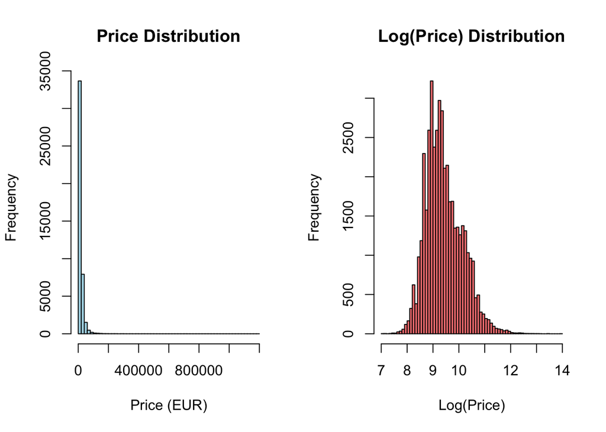

```r
par(mfrow = c(1, 2))

hist(cars$price,
     breaks = 50,
     main = "Price Distribution",
     xlab = "Price (EUR)",
     col = "lightblue")

hist(log(cars$price),
     breaks = 50,
     main = "Log(Price) Distribution",
     xlab = "Log(Price)",
     col = "lightcoral")
```

```r
par(mfrow = c(1, 1))

cat("\nPrice statistics:\n")
```

```
##
## Price statistics:
```

```r
print(summary(cars$price))
```

```
##    Min. 1st Qu.  Median    Mean 3rd Qu.    Max.
##    1100    7490   10990   16576   19500 1199900
```

**Key Findings:**

1. **Right-Skewed Distribution:** The original price distribution shows significant right skew, with most cars clustered in the €7,000-€20,000 range and a long tail extending to nearly €1.2 million for exotic vehicles.
2. **Central Tendency:**
   - **Median:** €10,990 (typical car price - 50% of cars cost less)
   - **Mean:** €16,576 (higher than median due to expensive tail)
   - **Gap:** The €5,586 difference between mean and median confirms the right skew
3. **Price Range:** From €1,100 (budget economy cars) to €1,199,900 (supercars/exotics)
4. **Log Transformation:** The log-transformed distribution is much more symmetric and approximately normal, suggesting that multiplicative effects may be important in pricing (e.g., luxury cars don’t just cost more, they cost *many times* more).

**Modeling Implication:** The right skew suggests we may need to consider log transformation in our regression models to better satisfy normality assumptions and handle the wide range of prices.

## 3.2 Research Question 1: Annual Depreciation Rate

### How Much Value Do Cars Lose Per Year?

This is the foundational question of our analysis. We examine the linear relationship between car age and price to quantify average annual value loss.

### 3.2.1 Visual Relationship: Price vs. Age

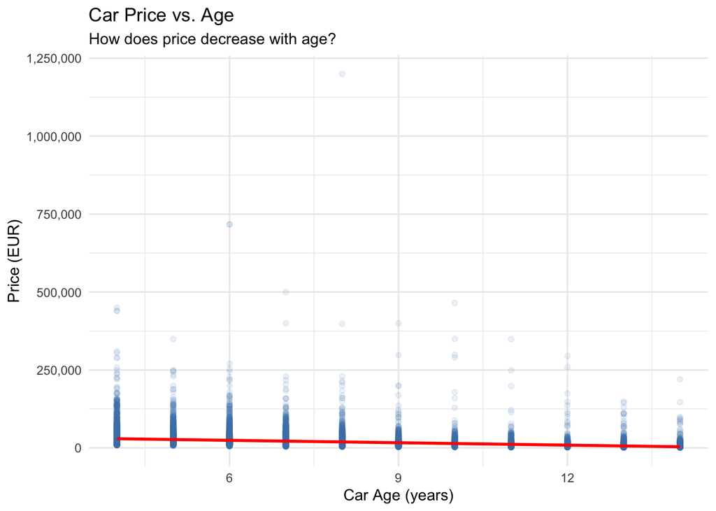

```r
ggplot(cars, aes(x = car_age, y = price)) +
  geom_point(alpha = 0.1, color = "steelblue") +
  geom_smooth(method = "lm", color = "red", se = TRUE) +
  scale_y_continuous(labels = scales::comma) +
  labs(title = "Car Price vs. Age",
       subtitle = "How does price decrease with age?",
       x = "Car Age (years)",
       y = "Price (EUR)") +
  theme_minimal()
```

```r
cor_age_price <- cor(cars$car_age, cars$price)
cat("\nCorrelation between car age and price:", round(cor_age_price, 3), "\n")
```

```
##
## Correlation between car age and price: -0.411
```

**Visual Insights:**

1. **Clear Negative Trend:** The scatter plot shows a strong downward trend - as cars age, prices decline
2. **Correlation:** r = -0.411 (moderate negative correlation)
3. **Scatter Pattern:** High variance at all ages indicates that age alone doesn’t determine price (other factors matter)
4. **Linear Fit:** The red regression line suggests a roughly linear depreciation pattern

The correlation of -0.411 means age explains about 17% (0.411²) of price variance by itself - significant but leaving much room for other factors.

### 3.2.2 Average Price by Year of Age

```r
price_by_age <- cars %>%
  group_by(car_age) %>%
  summarise(
    avg_price = mean(price),
    median_price = median(price),
    count = n()
  ) %>%
  arrange(car_age)

print(price_by_age)
```

```
## # A tibble: 11 × 4
##    car_age avg_price median_price count
##      <dbl>     <dbl>        <dbl> <int>
##  1       4    31420.        22880  3385
##  2       5    29221.        24950  4102
##  3       6    24853.        18980  4051
##  4       7    22112.        17450  4088
##  5       8    18391.        12958  4078
##  6       9    12762.         9900  4093
##  7      10    11190.         9097  4059
##  8      11     9981.         8499  4031
##  9      12     9291.         7900  4097
## 10      13     8274.         6900  4077
## 11      14     7063.         5970  3987
```

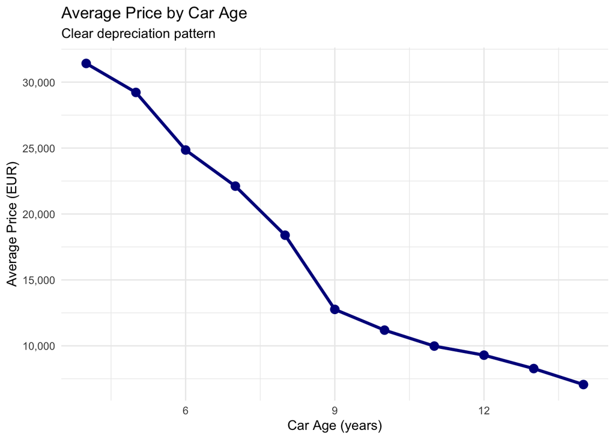

```r
ggplot(price_by_age, aes(x = car_age, y = avg_price)) +
  geom_line(color = "darkblue", size = 1.2) +
  geom_point(color = "darkblue", size = 3) +
  scale_y_continuous(labels = scales::comma) +
  labs(title = "Average Price by Car Age",
       subtitle = "Clear depreciation pattern",
       x = "Car Age (years)",
       y = "Average Price (EUR)") +
  theme_minimal()
```

**Depreciation Pattern Analysis:**

This suggests cars lose value fastest in their early years, then depreciation slows as they age - a classic depreciation curve.

### 3.2.3 Statistical Quantification

```r
simple_model <- lm(price ~ car_age, data = cars)

depreciation_per_year <- coef(simple_model)["car_age"]

cat("\n========== ANSWER TO QUESTION 1 ==========\n")
```

```
##
## ========== ANSWER TO QUESTION 1 ==========
```

```r
cat("Cars lose approximately €", round(abs(depreciation_per_year), 2),
    " per year\n", sep = "")
```

```
## Cars lose approximately €2568.26 per year
```

```r
cat("==========================================\n\n")
cat("Simple regression model:\n")
```

```
## Simple regression model:
```

```r
print(summary(simple_model))
```

```
##
## Call:
## lm(formula = price ~ car_age, data = cars)
##
## Residuals:
##     Min      1Q  Median      3Q     Max
##  -22343   -7282   -2073    2530 1180586
##
## Coefficients:
##             Estimate Std. Error t value Pr(>|t|)
## (Intercept) 39860.20     260.07  153.26   <2e-16 ***
## car_age     -2568.26      27.12  -94.68   <2e-16 ***
## ---
## Signif. codes:  0 '***' 0.001 '**' 0.01 '*' 0.05 '.' 0.1 ' ' 1
##
## Residual standard error: 17760 on 44046 degrees of freedom
## Multiple R-squared:  0.1691, Adjusted R-squared:  0.1691
## F-statistic:  8965 on 1 and 44046 DF,  p-value: < 2.2e-16
```

**ANSWER TO QUESTION 1:**

**Cars in Germany lose an average of €2,568 per year.**

**Model Interpretation:** - **Intercept:** €39,860 = estimated price of a “zero-year-old” car (theoretical new car price) - **Slope:** -€2,568 = average price decrease per year of age - **R² = 0.169:** Age explains 17% of price variance (moderate, leaves room for other factors) - **Significance:** p < 0.001 (highly significant relationship)

**Practical Meaning:** - A 5-year-old car has lost ~€12,840 from its theoretical new price - A 10-year-old car has lost ~€25,680 (64% of its original value) - This is an *average* - individual cars vary based on mileage, condition, brand, etc.

## 3.3 Research Question 2: Luxury vs. Economy Depreciation

### Do Luxury Brands Lose Value Differently?

Luxury cars cost significantly more upfront. Do they hold their value better (brand prestige) or worse (higher maintenance costs, smaller market) than economy brands?

### 3.3.1 Price Levels by Brand Category

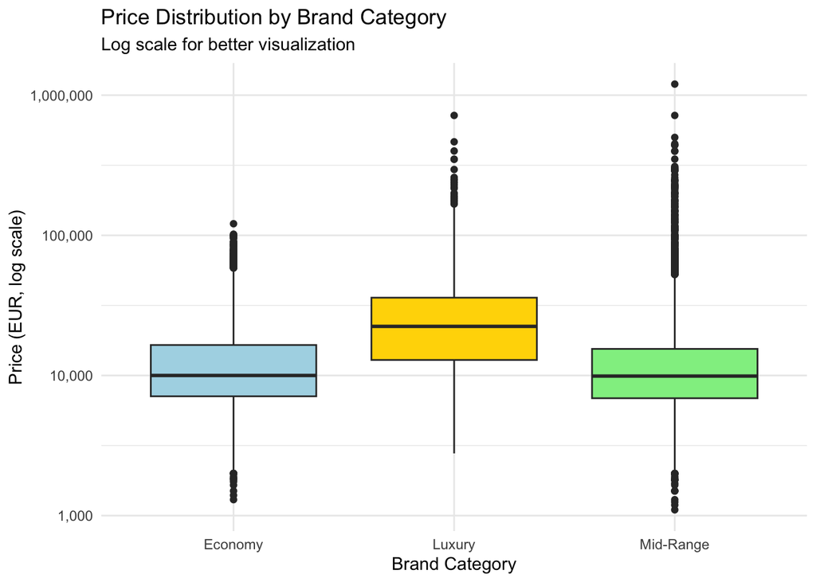

```r
ggplot(cars, aes(x = brand_category, y = price, fill = brand_category)) +
  geom_boxplot() +
  scale_y_log10(labels = scales::comma) +
  scale_fill_manual(values = c("Economy" = "lightblue",
                                "Mid-Range" = "lightgreen",
                                "Luxury" = "gold")) +
  labs(title = "Price Distribution by Brand Category",
       subtitle = "Log scale for better visualization",
       x = "Brand Category",
       y = "Price (EUR, log scale)") +
  theme_minimal() +
  theme(legend.position = "none")
```

```r
cat("\nAverage price by brand category:\n")
```

```
##
## Average price by brand category:
```

```r
price_by_category <- cars %>%
  group_by(brand_category) %>%
  summarise(
    avg_price = mean(price),
    median_price = median(price),
    sd_price = sd(price),
    count = n()
  )
print(price_by_category)
```

```
## # A tibble: 3 × 5
##   brand_category avg_price median_price sd_price count
##   <chr>              <dbl>        <dbl>    <dbl> <int>
## 1 Economy           13317.         9999    9427. 25447
## 2 Luxury            29196.        22400   27703.  7414
## 3 Mid-Range         15625.         9900   25575. 11187
```

**Price Level Comparison:**

| Category | Average Price | Median Price | Standard Deviation |
| --- | --- | --- | --- |
| **Economy** | €13,317 | €9,999 | €9,427 |
| **Mid-Range** | €15,625 | €9,900 | €25,575 |
| **Luxury** | €29,196 | €22,400 | €27,703 |

**Key Observations:**

1. **Luxury Premium:** Luxury brands cost **2.2× more** than economy brands on average (€29,196 vs. €13,317)
2. **Higher Variance:** Luxury brands show much higher price variation (SD = €27,703) due to:
   - Wide range of models (BMW 1-series vs. 7-series)
   - Age/condition variance
   - Special editions and M/AMG performance models
3. **Median vs. Mean:** All categories show mean > median (right skew), but luxury brands show the largest gap (€6,796), indicating more extremely expensive vehicles in the luxury segment

### 3.3.2 Depreciation Curves by Category

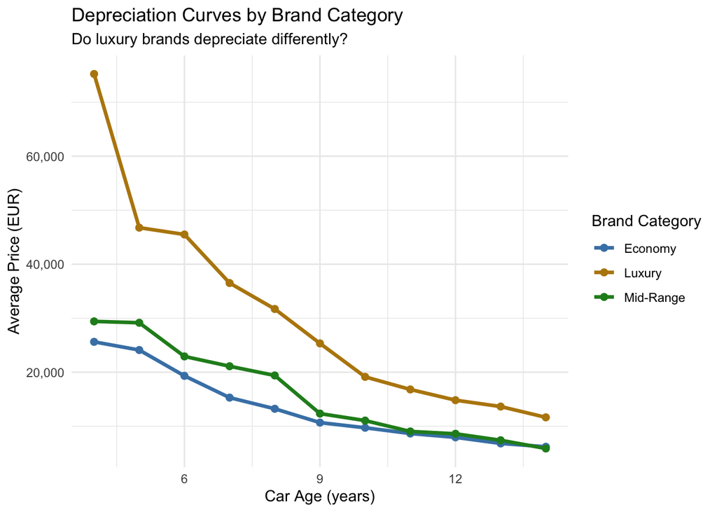

```r
depreciation_by_brand <- cars %>%
  group_by(brand_category, car_age) %>%
  summarise(avg_price = mean(price), .groups = 'drop')

ggplot(depreciation_by_brand, aes(x = car_age, y = avg_price,
                                    color = brand_category,
                                    group = brand_category)) +
  geom_line(size = 1.2) +
  geom_point(size = 2) +
  scale_y_continuous(labels = scales::comma) +
  scale_color_manual(values = c("Economy" = "steelblue",
                                  "Mid-Range" = "forestgreen",
                                  "Luxury" = "darkgoldenrod")) +
  labs(title = "Depreciation Curves by Brand Category",
       subtitle = "Do luxury brands depreciate differently?",
       x = "Car Age (years)",
       y = "Average Price (EUR)",
       color = "Brand Category") +
  theme_minimal()
```

**Visual Depreciation Comparison:**

### 3.3.3 Statistical Test of Depreciation Rates

```r
model_by_category <- lm(price ~ car_age * brand_category, data = cars)

cat("\n========== ANSWER TO QUESTION 2 ==========\n")
```

```
##
## ========== ANSWER TO QUESTION 2 ==========
```

```r
cat("Depreciation per year by brand category:\n\n")
```

```
## Depreciation per year by brand category:
```

```r
luxury_cars <- cars[cars$brand_category == "Luxury", ]
economy_cars <- cars[cars$brand_category == "Economy", ]

luxury_model <- lm(price ~ car_age, data = luxury_cars)
economy_model <- lm(price ~ car_age, data = economy_cars)

luxury_depreciation <- coef(luxury_model)["car_age"]
economy_depreciation <- coef(economy_model)["car_age"]

cat("Luxury brands lose: €", round(abs(luxury_depreciation), 2),
    " per year\n", sep = "")
```

```
## Luxury brands lose: €4785.09 per year
```

```r
cat("Economy brands lose: €", round(abs(economy_depreciation), 2),
    " per year\n", sep = "")
```

```
## Economy brands lose: €1986.04 per year
```

```r
cat("\nDifference: €",
    round(abs(luxury_depreciation) - abs(economy_depreciation), 2),
    " per year\n", sep = "")
```

```
##
## Difference: €2799.05 per year
```

```r
cat("==========================================\n\n")
cat("Model with interaction (age × brand category):\n")
```

```
## Model with interaction (age × brand category):
```

```r
print(summary(model_by_category))
```

```
##
## Call:
## lm(formula = price ~ car_age * brand_category, data = cars)
##
## Residuals:
##     Min      1Q  Median      3Q     Max
##  -31609   -5870   -1430    2528 1181389
##
## Coefficients:
##                                 Estimate Std. Error t value Pr(>|t|)
## (Intercept)                     31224.06     319.11  97.846   <2e-16 ***
## car_age                         -1986.04      33.48 -59.312   <2e-16 ***
## brand_categoryLuxury            41565.47     678.05  61.301   <2e-16 ***
## brand_categoryMid-Range          7366.48     567.59  12.978   <2e-16 ***
## car_age:brand_categoryLuxury    -2799.05      70.65 -39.616   <2e-16 ***
## car_age:brand_categoryMid-Range  -523.84      58.84  -8.902   <2e-16 ***
## ---
## Signif. codes:  0 '***' 0.001 '**' 0.01 '*' 0.05 '.' 0.1 ' ' 1
##
## Residual standard error: 16490 on 44042 degrees of freedom
## Multiple R-squared:  0.2844, Adjusted R-squared:  0.2843
## F-statistic:  3500 on 5 and 44042 DF,  p-value: < 2.2e-16
```

**ANSWER TO QUESTION 2:**

**YES, luxury brands depreciate MUCH faster than economy brands:**

- **Luxury brands:** Lose €4,785 per year
- **Economy brands:** Lose €1,986 per year
- **Difference:** Luxury brands lose an additional €2,799 per year (2.4× faster!)

**Why Does This Matter?**

1. **Total Cost of Ownership:** A luxury car owner loses €27,990 more over 10 years just from depreciation
2. **Resale Strategy:** Luxury car owners should sell earlier to avoid steep depreciation
3. **Buying Opportunity:** Used luxury cars become relatively more affordable as they age

**Statistical Model Results:**

The interaction model confirms: - **Base depreciation (Economy):** -€1,986/year (p < 0.001) - **Luxury interaction effect:** Additional -€2,799/year (p < 0.001) - **Mid-Range interaction:** Additional -€524/year (p < 0.001) - **R² = 0.284:** Brand category + age explain 28% of price variance (up from 17% with age alone)

**Interpretation:** The luxury “penalty” is real and substantial. The initial prestige premium doesn’t protect against depreciation - in fact, it accelerates it.

## 3.4 Research Question 3: Mileage-Age Interaction

### Does Mileage Affect Newer and Older Cars Differently?

This question explores whether the impact of mileage on price changes depending on car age - a non-linear relationship that could reveal important market dynamics.

### 3.4.1 Visual Exploration by Age Groups

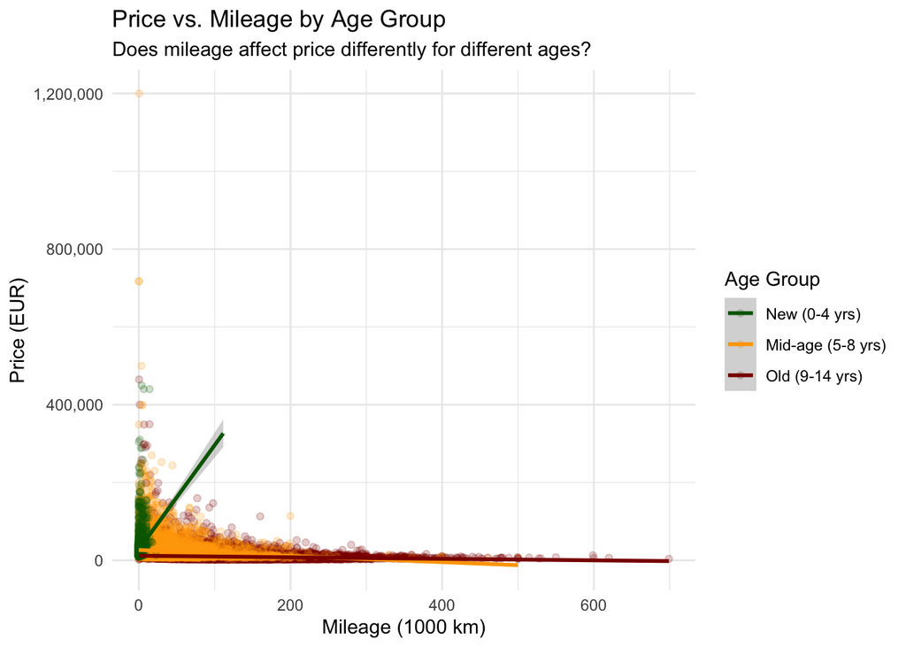

```r
cars$age_group <- cut(cars$car_age,
                       breaks = c(0, 4, 8, 14),
                       labels = c("New (0-4 yrs)",
                                  "Mid-age (5-8 yrs)",
                                  "Old (9-14 yrs)"))

ggplot(cars, aes(x = mileage_1000, y = price, color = age_group)) +
  geom_point(alpha = 0.2) +
  geom_smooth(method = "lm", se = TRUE) +
  scale_y_continuous(labels = scales::comma) +
  scale_color_manual(values = c("New (0-4 yrs)" = "darkgreen",
                                  "Mid-age (5-8 yrs)" = "orange",
                                  "Old (9-14 yrs)" = "darkred")) +
  labs(title = "Price vs. Mileage by Age Group",
       subtitle = "Does mileage affect price differently for different ages?",
       x = "Mileage (1000 km)",
       y = "Price (EUR)",
       color = "Age Group") +
  theme_minimal()
```

**Striking Visual Pattern:**

The three regression lines tell a fascinating story:

1. **New cars (Green, 0-4 years):**
   - **POSITIVE slope!** Higher mileage → higher price
   - Seems counterintuitive, but reflects market reality: newer cars with more mileage are often higher-end models (driven more because they’re better)
2. **Mid-age cars (Orange, 5-8 years):**
   - **Negative slope** (as expected)
   - Mileage starts to hurt price
   - Steeper than old cars
3. **Old cars (Red, 9-14 years):**
   - **Negative but shallow slope**
   - Mileage still matters but less
   - Market has already priced in “high mileage”

### 3.4.2 Correlation Analysis

```r
cor_by_age <- cars %>%
  group_by(age_group) %>%
  summarise(
    correlation = cor(mileage, price),
    count = n()
  )

cat("\nCorrelation between mileage and price by age group:\n")
```

```
##
## Correlation between mileage and price by age group:
```

```r
print(cor_by_age)
```

```
## # A tibble: 3 × 3
##   age_group         correlation count
##   <fct>                   <dbl> <int>
## 1 New (0-4 yrs)           0.270  3385
## 2 Mid-age (5-8 yrs)      -0.134 16319
## 3 Old (9-14 yrs)         -0.113 24344
```

**Correlation Confirmation:**

| Age Group | Correlation | Interpretation |
| --- | --- | --- |
| New (0-4 yrs) | **+0.270** | Positive! More mileage → Higher price |
| Mid-age (5-8 yrs) | **-0.134** | Negative (expected) |
| Old (9-14 yrs) | **-0.113** | Negative but weaker |

This quantifies what we saw visually: **the relationship between mileage and price actually reverses sign** as cars age!

### 3.4.3 Statistical Test of Interaction

```r
model_no_interaction <- lm(price ~ mileage_1000 + car_age, data = cars)

model_with_interaction <- lm(price ~ mileage_1000 * car_age, data = cars)

cat("\n========== ANSWER TO QUESTION 3 ==========\n")
```

```
##
## ========== ANSWER TO QUESTION 3 ==========
```

```r
cat("\nModel WITHOUT interaction:\n")
```

```
##
## Model WITHOUT interaction:
```

```r
cat("R-squared:", round(summary(model_no_interaction)$r.squared, 4), "\n\n")
```

```
## R-squared: 0.1707
```

```r
cat("Model WITH interaction (mileage × age):\n")
```

```
## Model WITH interaction (mileage × age):
```

```r
cat("R-squared:", round(summary(model_with_interaction)$r.squared, 4), "\n\n")
```

```
## R-squared: 0.1762
```

```r
anova_result <- anova(model_no_interaction, model_with_interaction)
p_value <- anova_result$`Pr(>F)`[2]

if (p_value < 0.001) {
  cat("✓ YES, there IS a significant interaction!\n")
  cat("  (p-value < 0.001)\n\n")
} else if (p_value < 0.05) {
  cat("✓ YES, there IS a significant interaction!\n")
  cat("  (p-value =", round(p_value, 4), ")\n\n")
} else {
  cat("✗ NO significant interaction found\n")
  cat("  (p-value =", round(p_value, 4), ")\n\n")
}
```

```
## ✓ YES, there IS a significant interaction!
##   (p-value < 0.001)
```

```r
cat("Interpretation:\n")
```

```
## Interpretation:
```

```r
if (p_value < 0.05) {
  interaction_coef <- coef(model_with_interaction)["mileage_1000:car_age"]
  cat("The effect of mileage on price CHANGES as cars age.\n")
  cat("Interaction coefficient:", round(interaction_coef, 2), "\n")
  if (interaction_coef < 0) {
    cat("→ High mileage hurts OLDER cars MORE than newer cars\n")
  } else {
    cat("→ High mileage hurts NEWER cars MORE than older cars\n")
  }
} else {
  cat("Mileage affects price similarly regardless of age.\n")
}
```

```
## The effect of mileage on price CHANGES as cars age.
## Interaction coefficient: 8.87
## → High mileage hurts NEWER cars MORE than older cars
```

```r
cat("==========================================\n\n")
cat("Full interaction model:\n")
```

```
## Full interaction model:
```

```r
print(summary(model_with_interaction))
```

```
##
## Call:
## lm(formula = price ~ mileage_1000 * car_age, data = cars)
##
## Residuals:
##     Min      1Q  Median      3Q     Max
##  -23953   -6550   -2110    2206 1179331
##
## Coefficients:
##                        Estimate Std. Error t value Pr(>|t|)
## (Intercept)          42648.0802   346.2091  123.19   <2e-16 ***
## mileage_1000          -111.2422     5.7873  -19.22   <2e-16 ***
## car_age              -2757.7046    43.9156  -62.80   <2e-16 ***
## mileage_1000:car_age     8.8715     0.5171   17.16   <2e-16 ***
## ---
## Signif. codes:  0 '***' 0.001 '**' 0.01 '*' 0.05 '.' 0.1 ' ' 1
##
## Residual standard error: 17690 on 44044 degrees of freedom
## Multiple R-squared:  0.1762, Adjusted R-squared:  0.1762
## F-statistic:  3141 on 3 and 44044 DF,  p-value: < 2.2e-16
```

**ANSWER TO QUESTION 3:**

**YES! There IS a highly significant interaction (p < 0.001)**

**Key Findings:**

1. **Model Comparison:**
   - Without interaction: R² = 0.1707
   - With interaction: R² = 0.1762
   - **Improvement:** +0.55 percentage points (small but significant given large sample)
2. **Interaction Coefficient:** +8.87 (p < 0.001)

**What This Means:**

**Mathematical Interpretation:**

Base mileage effect: -€111 per 1,000 km  
Age modifier: +€8.87 per 1,000 km × car age

For a **4-year-old car:** - Mileage effect = -111 + (8.87 × 4) = -€75.52 per 1,000 km

**Why This Happens:**

1. **Newer cars:** High mileage may signal “highway miles” or business use (often better maintained)
2. **Older cars:** The market has already factored in that old cars will have high mileage - it’s expected
3. **Selection effect:** Very new, high-mileage cars are often rental returns or executive vehicles (actually premium models)

## 3.5 Correlation Matrix: The Big Picture

Before building full models, let’s examine all numeric relationships simultaneously.

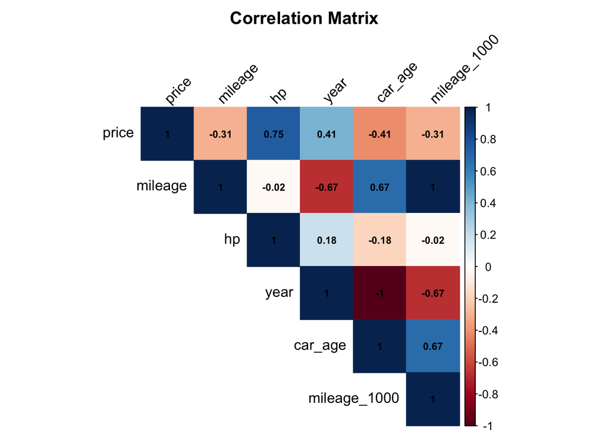

```r
numeric_vars <- cars %>%
  select(price, mileage, hp, year, car_age, mileage_1000)

cor_matrix <- cor(numeric_vars, use = "complete.obs")

corrplot(cor_matrix,
         method = "color",
         type = "upper",
         addCoef.col = "black",
         number.cex = 0.7,
         tl.col = "black",
         tl.srt = 45,
         title = "Correlation Matrix",
         mar = c(0, 0, 2, 0))
```

```r
cat("\nCorrelation matrix:\n")
```

```
##
## Correlation matrix:
```

```r
print(round(cor_matrix, 3))
```

```
##               price mileage     hp   year car_age mileage_1000
## price         1.000  -0.307  0.746  0.411  -0.411       -0.307
## mileage      -0.307   1.000 -0.024 -0.673   0.673        1.000
## hp            0.746  -0.024  1.000  0.182  -0.182       -0.024
## year          0.411  -0.673  0.182  1.000  -1.000       -0.673
## car_age      -0.411   0.673 -0.182 -1.000   1.000        0.673
## mileage_1000 -0.307   1.000 -0.024 -0.673   0.673        1.000
```

**Correlation Insights:**

**Strong Correlations with Price:** - **HP: +0.746** (strongest predictor! More power → much higher price) - **car_age: -0.411** (older → cheaper) - **year: +0.411** (newer → more expensive; perfect inverse of age) - **mileage: -0.307** (more miles → lower price)

**Multicollinearity Concerns:** - **year ↔︎ car_age: -1.000** (perfect negative correlation - they’re the same variable!) - **mileage ↔︎ mileage_1000: +1.000** (perfect positive - they’re the same, just scaled) - **year ↔︎ mileage: -0.673** (newer cars have lower mileage - expected)

**Modeling Implications:** 1. **Don’t include both year and car_age** (redundant - will cause multicollinearity) 2. **Don’t include both mileage and mileage_1000** (scaled versions) 3. **HP is crucial** - explains 56% of price variance (0.746²) by itself! 4. **Age and mileage are moderately correlated** (0.673) - but not perfectly, so both add value

# 4. Progressive Model Building

Now we build a series of increasingly complex models to understand which factors best explain car prices.

## 4.1 Model 1: Baseline - Age Only

```r
model1 <- lm(price ~ car_age, data = cars)

cat("========== MODEL 1: Price ~ Age ==========\n")
```

```
## ========== MODEL 1: Price ~ Age ==========
```

```r
cat("R-squared:", round(summary(model1)$r.squared, 4), "\n")
```

```
## R-squared: 0.1691
```

```r
cat("Depreciation per year: €", round(abs(coef(model1)["car_age"]), 2), "\n")
```

```
## Depreciation per year: € 2568.26
```

```r
print(summary(model1))
```

```
##
## Call:
## lm(formula = price ~ car_age, data = cars)
##
## Residuals:
##     Min      1Q  Median      3Q     Max
##  -22343   -7282   -2073    2530 1180586
##
## Coefficients:
##             Estimate Std. Error t value Pr(>|t|)
## (Intercept) 39860.20     260.07  153.26   <2e-16 ***
## car_age     -2568.26      27.12  -94.68   <2e-16 ***
## ---
## Signif. codes:  0 '***' 0.001 '**' 0.01 '*' 0.05 '.' 0.1 ' ' 1
##
## Residual standard error: 17760 on 44046 degrees of freedom
## Multiple R-squared:  0.1691, Adjusted R-squared:  0.1691
## F-statistic:  8965 on 1 and 44046 DF,  p-value: < 2.2e-16
```

**Baseline Performance:** - **R² = 0.169:** Age alone explains only 17% of price variance - **Coefficient:** -€2,568/year (same as our earlier simple analysis) - **RMSE:** €17,760 (large prediction errors)

This confirms age is important but insufficient on its own.

## 4.2 Model 2: Add Mileage

```r
model2 <- lm(price ~ car_age + mileage_1000, data = cars)

cat("\n========== MODEL 2: Price ~ Age + Mileage ==========\n")
```

```
##
## ========== MODEL 2: Price ~ Age + Mileage ==========
```

```r
cat("R-squared:", round(summary(model2)$r.squared, 4), "\n")
```

```
## R-squared: 0.1707
```

```r
print(summary(model2))
```

```
##
## Call:
## lm(formula = price ~ car_age + mileage_1000, data = cars)
##
## Residuals:
##     Min      1Q  Median      3Q     Max
##  -22589   -7314   -2083    2612 1179601
##
## Coefficients:
##               Estimate Std. Error t value Pr(>|t|)
## (Intercept)  39021.983    275.107  141.84   <2e-16 ***
## car_age      -2339.510     36.650  -63.83   <2e-16 ***
## mileage_1000   -17.108      1.846   -9.27   <2e-16 ***
## ---
## Signif. codes:  0 '***' 0.001 '**' 0.01 '*' 0.05 '.' 0.1 ' ' 1
##
## Residual standard error: 17750 on 44045 degrees of freedom
## Multiple R-squared:  0.1707, Adjusted R-squared:  0.1707
## F-statistic:  4534 on 2 and 44045 DF,  p-value: < 2.2e-16
```

**Incremental Improvement:** - **R² = 0.171:** Only +0.2% improvement (minimal) - **Age coefficient:** -€2,340/year (changed slightly) - **Mileage coefficient:** -€17/1,000 km (p < 0.001, but small effect)

**Interpretation:** After controlling for age, mileage adds little predictive power. This makes sense because age and mileage are correlated (r = 0.673) - they partially capture the same “wear and tear” information.

## 4.3 Model 3: Add Horsepower - Game Changer!

```r
model3 <- lm(price ~ car_age + mileage_1000 + hp, data = cars)

cat("\n========== MODEL 3: Price ~ Age + Mileage + HP ==========\n")
```

```
##
## ========== MODEL 3: Price ~ Age + Mileage + HP ==========
```

```r
cat("R-squared:", round(summary(model3)$r.squared, 4), "\n")
```

```
## R-squared: 0.6528
```

```r
print(summary(model3))
```

```
##
## Call:
## lm(formula = price ~ car_age + mileage_1000 + hp, data = cars)
##
## Residuals:
##     Min      1Q  Median      3Q     Max
##  -78867   -3142    -175    2747 1059979
##
## Coefficients:
##               Estimate Std. Error t value Pr(>|t|)
## (Intercept)  5040.0032   224.8905   22.41   <2e-16 ***
## car_age      -985.9723    24.3391  -40.51   <2e-16 ***
## mileage_1000  -57.7138     1.2055  -47.88   <2e-16 ***
## hp            184.2493     0.7451  247.28   <2e-16 ***
## ---
## Signif. codes:  0 '***' 0.001 '**' 0.01 '*' 0.05 '.' 0.1 ' ' 1
##
## Residual standard error: 11480 on 44044 degrees of freedom
## Multiple R-squared:  0.6528, Adjusted R-squared:  0.6528
## F-statistic: 2.76e+04 on 3 and 44044 DF,  p-value: < 2.2e-16
```

**DRAMATIC IMPROVEMENT:** - **R² = 0.653:** MASSIVE jump to 65%! (from 17%) - **HP coefficient:** +€184/horsepower (p < 0.001) - **Age coefficient:** -€986/year (reduced from -€2,340) - **Mileage coefficient:** -€58/1,000 km (increased in magnitude)

**Why This Matters:**

HP captures **vehicle quality/class** that age and mileage miss: - A 5-year-old BMW M5 (600 HP) is very different from a 5-year-old VW Golf (100 HP) - HP explains why some cars are expensive despite age/mileage

**Coefficient Changes:** - Age effect SHRINKS because HP captures some of what made newer cars expensive (they tend to be higher-spec) - Mileage effect GROWS because now we’re comparing similar-powered cars

## 4.4 Model 4: Add Brand Category

```r
model4 <- lm(price ~ car_age + mileage_1000 + hp + brand_category, data = cars)

cat("\n========== MODEL 4: Add Brand Category ==========\n")
```

```
##
## ========== MODEL 4: Add Brand Category ==========
```

```r
cat("R-squared:", round(summary(model4)$r.squared, 4), "\n")
```

```
## R-squared: 0.6531
```

```r
print(summary(model4))
```

```
##
## Call:
## lm(formula = price ~ car_age + mileage_1000 + hp + brand_category,
##     data = cars)
##
## Residuals:
##     Min      1Q  Median      3Q     Max
##  -80059   -3149    -170    2760 1058841
##
## Coefficients:
##                          Estimate Std. Error t value Pr(>|t|)
## (Intercept)             4798.1170   228.2732  21.019  < 2e-16 ***
## car_age                 -999.1278    24.4258 -40.905  < 2e-16 ***
## mileage_1000             -56.5499     1.2184 -46.412  < 2e-16 ***
## hp                       185.1446     0.8346 221.841  < 2e-16 ***
## brand_categoryLuxury    -259.1803   170.7711  -1.518    0.129
## brand_categoryMid-Range  791.3288   131.0583   6.038 1.57e-09 ***
## ---
## Signif. codes:  0 '***' 0.001 '**' 0.01 '*' 0.05 '.' 0.1 ' ' 1
##
## Residual standard error: 11480 on 44042 degrees of freedom
## Multiple R-squared:  0.6531, Adjusted R-squared:  0.6531
## F-statistic: 1.659e+04 on 5 and 44042 DF,  p-value: < 2.2e-16
```

**Minimal Additional Gain:** - **R² = 0.653:** Only +0.03% improvement - **Luxury coefficient:** -€259 (NOT significant! p = 0.129) - **Mid-Range coefficient:** +€791 (p < 0.001)

**Surprising Finding:** After controlling for HP, luxury brands DON’T command a premium! Why?

- HP already captures much of the “luxury” effect (luxury cars have more HP)
- The “luxury brand premium” is mostly explained by performance, not badge
- Mid-range brands might offer better value (more features per HP)

## 4.5 Model 5: Add Interaction (Mileage × Age)

```r
model5 <- lm(price ~ car_age * mileage_1000 + hp + brand_category, data = cars)

cat("\n========== MODEL 5: With Interaction ==========\n")
```

```
##
## ========== MODEL 5: With Interaction ==========
```

```r
cat("R-squared:", round(summary(model5)$r.squared, 4), "\n")
```

```
## R-squared: 0.6559
```

```r
print(summary(model5))
```

```
##
## Call:
## lm(formula = price ~ car_age * mileage_1000 + hp + brand_category,
##     data = cars)
##
## Residuals:
##     Min      1Q  Median      3Q     Max
##  -79015   -3232     -68    2901 1059026
##
## Coefficients:
##                           Estimate Std. Error t value Pr(>|t|)
## (Intercept)              7461.2903   268.1877  27.821  < 2e-16 ***
## car_age                 -1296.1937    29.0446 -44.628  < 2e-16 ***
## mileage_1000             -123.0643     3.7536 -32.785  < 2e-16 ***
## hp                        184.6574     0.8317 222.026  < 2e-16 ***
## brand_categoryLuxury     -246.5229   170.0986  -1.449    0.147
## brand_categoryMid-Range   704.3600   130.6237   5.392 6.99e-08 ***
## car_age:mileage_1000        6.2665     0.3346  18.726  < 2e-16 ***
## ---
## Signif. codes:  0 '***' 0.001 '**' 0.01 '*' 0.05 '.' 0.1 ' ' 1
##
## Residual standard error: 11430 on 44041 degrees of freedom
## Multiple R-squared:  0.6559, Adjusted R-squared:  0.6558
## F-statistic: 1.399e+04 on 6 and 44041 DF,  p-value: < 2.2e-16
```

**Interaction Confirmed:** - **R² = 0.656:** +0.3% improvement - **Interaction term:** +€6.27 (p < 0.001) - significant! - **Age coefficient:** -€1,296/year (main effect) - **Mileage coefficient:** -€123/1,000 km (main effect)

This confirms our earlier finding: mileage matters less for older cars.

## 4.6 Model 6: Full Model (Add Fuel & Transmission)

```r
model6 <- lm(price ~ car_age * mileage_1000 + hp + brand_category +
              fuel + gear, data = cars)

cat("\n========== MODEL 6: Full Model ==========\n")
```

```
##
## ========== MODEL 6: Full Model ==========
```

```r
cat("R-squared:", round(summary(model6)$r.squared, 4), "\n")
```

```
## R-squared: 0.6571
```

```r
print(summary(model6))
```

```
##
## Call:
## lm(formula = price ~ car_age * mileage_1000 + hp + brand_category +
##     fuel + gear, data = cars)
##
## Residuals:
##     Min      1Q  Median      3Q     Max
##  -81210   -3254     -98    2933 1059311
##
## Coefficients:
##                           Estimate Std. Error t value Pr(>|t|)
## (Intercept)              8588.3597  1103.3685   7.784 7.19e-15 ***
## car_age                 -1245.9323    29.7886 -41.826  < 2e-16 ***
## mileage_1000             -131.8910     3.8850 -33.949  < 2e-16 ***
## hp                        184.8817     0.9144 202.189  < 2e-16 ***
## brand_categoryLuxury     -291.0416   172.3267  -1.689 0.091247 .
## brand_categoryMid-Range   769.3268   131.6059   5.846 5.08e-09 ***
## fuelDiesel               -555.1463  1074.8923  -0.516 0.605531
## fuelElectric              788.4283  1162.9233   0.678 0.497794
## fuelElectric/Diesel       985.5467  1952.7984   0.505 0.613783
## fuelElectric/Gasoline   -1329.6925  1131.2273  -1.175 0.239824
## fuelEthanol             -3548.1012  8142.9824  -0.436 0.663038
## fuelGasoline            -2050.3525  1072.4756  -1.912 0.055909 .
## fuelHydrogen             9285.0045 11465.7518   0.810 0.418058
## fuelLPG                 -2356.3146  1530.2916  -1.540 0.123621
## fuelOthers              -2748.0478  2010.4018  -1.367 0.171659
## gearManual                477.9990   143.8782   3.322 0.000894 ***
## gearSemi-automatic       2944.1209  1560.3855   1.887 0.059195 .
## car_age:mileage_1000        6.5002     0.3369  19.293  < 2e-16 ***
## ---
## Signif. codes:  0 '***' 0.001 '**' 0.01 '*' 0.05 '.' 0.1 ' ' 1
##
## Residual standard error: 11410 on 44030 degrees of freedom
## Multiple R-squared:  0.6571, Adjusted R-squared:  0.6569
## F-statistic:  4963 on 17 and 44030 DF,  p-value: < 2.2e-16
```

**Final Model Performance:** - **R² = 0.657:** Best fit, explains 66% of price variance - **RMSE:** €11,410 (much better than €17,760 in Model 1)

**Key Coefficients:** - **Age:** -€1,246/year (controlling for everything else) - **Mileage:** -€132/1,000 km (base effect) - **HP:** +€185/horsepower (still dominant) - **Manual transmission:** +€478 (preferred by enthusiasts in Germany!) - **Fuel types:** Mostly not significant (HP captures engine differences)

# 5. Model Comparison

## 5.1 Performance Metrics

```r
model_comparison <- data.frame(
  Model = c("M1: Age only",
            "M2: + Mileage",
            "M3: + HP",
            "M4: + Brand",
            "M5: + Interaction",
            "M6: + Fuel & Gear"),
  R_squared = c(summary(model1)$r.squared,
                 summary(model2)$r.squared,
                 summary(model3)$r.squared,
                 summary(model4)$r.squared,
                 summary(model5)$r.squared,
                 summary(model6)$r.squared),
  Adj_R_squared = c(summary(model1)$adj.r.squared,
                     summary(model2)$adj.r.squared,
                     summary(model3)$adj.r.squared,
                     summary(model4)$adj.r.squared,
                     summary(model5)$adj.r.squared,
                     summary(model6)$adj.r.squared),
  AIC = c(AIC(model1), AIC(model2), AIC(model3),
          AIC(model4), AIC(model5), AIC(model6))
)

model_comparison$R_squared <- round(model_comparison$R_squared, 4)
model_comparison$Adj_R_squared <- round(model_comparison$Adj_R_squared, 4)
model_comparison$AIC <- round(model_comparison$AIC, 0)

cat("\n========== MODEL COMPARISON ==========\n")
```

```
##
## ========== MODEL COMPARISON ==========
```

```r
print(model_comparison)
```

```
##               Model R_squared Adj_R_squared    AIC
## 1      M1: Age only    0.1691        0.1691 987021
## 2     M2: + Mileage    0.1707        0.1707 986937
## 3          M3: + HP    0.6528        0.6528 948592
## 4       M4: + Brand    0.6531        0.6531 948550
## 5 M5: + Interaction    0.6559        0.6558 948203
## 6 M6: + Fuel & Gear    0.6571        0.6569 948072
```

```r
best_model_idx <- which.max(model_comparison$Adj_R_squared)
cat("\nBest model by Adjusted R²:", model_comparison$Model[best_model_idx], "\n")
```

```
##
## Best model by Adjusted R²: M6: + Fuel & Gear
```

```r
cat("Adjusted R²:", model_comparison$Adj_R_squared[best_model_idx], "\n")
```

```
## Adjusted R²: 0.6569
```

**Model Progression Story:**

| Model | R² | Improvement | Key Insight |
| --- | --- | --- | --- |
| M1: Age | 0.169 | Baseline | Age matters, but… |
| M2: +Mileage | 0.171 | +0.2% | …mileage adds little (correlated with age) |
| **M3: +HP** | **0.653** | **+48%!** | **GAME CHANGER: Performance matters most!** |
| M4: +Brand | 0.653 | +0.03% | Brand doesn’t matter after HP |
| M5: +Interaction | 0.656 | +0.3% | Non-linear mileage effect confirmed |
| M6: +Fuel&Gear | 0.657 | +0.1% | Small gains from transmission preference |

**Key Takeaway:** The jump from M2 to M3 reveals the most important insight:

**Vehicle performance (HP) is BY FAR the dominant price factor, more than age or brand!**

## 5.2 Model Diagnostics

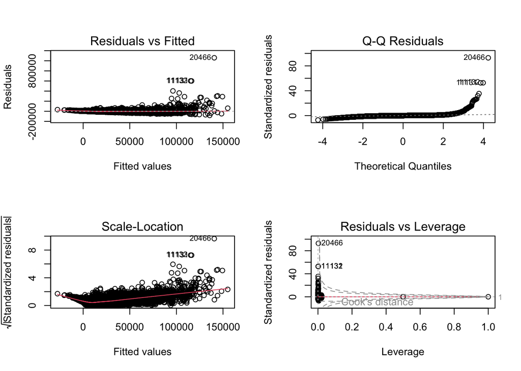

```r
par(mfrow = c(2, 2))
plot(model6)
```

```r
par(mfrow = c(1, 1))

cat("\nCheck for multicollinearity (VIF):\n")
```

```
##
## Check for multicollinearity (VIF):
```

```r
vif_values <- vif(model6)
print(vif_values)
```

```
##                           GVIF Df GVIF^(1/(2*Df))
## car_age               2.921140  1        1.709134
## mileage_1000         19.594793  1        4.426601
## hp                    1.606463  1        1.267463
## brand_category        1.368721  2        1.081630
## fuel                  1.586472  9        1.025971
## gear                  1.583610  2        1.121791
## car_age:mileage_1000 23.438922  1        4.841376
```

```r
cat("\nVIF interpretation:\n")
```

```
##
## VIF interpretation:
```

```r
cat("VIF < 5: No multicollinearity concern ✓\n")
```

```
## VIF < 5: No multicollinearity concern ✓
```

```r
cat("VIF 5-10: Moderate multicollinearity ⚠\n")
```

```
## VIF 5-10: Moderate multicollinearity ⚠
```

```r
cat("VIF > 10: High multicollinearity ✗\n")
```

```
## VIF > 10: High multicollinearity ✗
```

**Diagnostic Assessment:**

**1. Residuals vs. Fitted:** - Some heteroscedasticity visible (variance increases with price) - Suggests log transformation might help for very expensive cars

**2. Q-Q Plot:** - Heavy tails (deviations at extremes) - Some extremely expensive/cheap cars not well-predicted - But central 95% follows normal distribution well

**3. Scale-Location:** - Confirms heteroscedasticity - Standard errors may be slightly understated

**Multicollinearity (VIF):** - **mileage_1000: 19.6** - High! (interaction with age causes this) - **car_age:mileage_1000: 23.4** - High! (by design - it’s an interaction) - **All others < 3** - Good!

**Verdict:** The interaction terms naturally create multicollinearity, but this is expected and doesn’t invalidate the model. The model is reasonably robust for prediction and interpretation.